# Danish Kings

Bo Hallum

7. Marts 2025

The task here is to load your Danish Monarchs csv into R using the `tidyverse` toolkit, calculate and explore the kings’ duration of reign with pipes `%>%` in `dplyr` and plot it over time.

## 1. Load the kings

```r
# FILL IN THE CODE BELOW and review the outputs
library(tidyverse)
kings <- read_csv("data/danskemonarker - Ark1.csv", na =c("NA", ""))
```

Answer: 1. Which of these functions is a `tidyverse` function? Read data with it below into a `kings` object

```r
# COMPLETE THE BLANKS BELOW WITH YOUR CODE, then turn the 'eval' flag in this chunk to TRUE.


class(kings)
```

```
## [1] "spec_tbl_df" "tbl_df"      "tbl"         "data.frame"
```

```r
ncol(kings)
```

```
## [1] 6
```

```r
head(kings)
```

```
## # A tibble: 6 × 6
##   Titel     Fødselsaar Dødsaar Start_regeringsperiode Slut_regeringaar Antal_aar
##   <chr>          <dbl>   <dbl>                  <dbl>            <dbl>     <dbl>
## 1 Gorm_den…         NA     958                    936              958        NA
## 2 Harlad_B…         NA     987                    958              987        29
## 3 Svend_Tv…         NA    1014                    987             1014        27
## 4 Harlad_2          NA    1018                   1014             1018         4
## 5 Knud_den…        995    1035                   1018             1035        17
## 6 Hardeknud       1020    1042                   1035             1042         7
```

```r
tail(kings)
```

```
## # A tibble: 6 × 6
##   Titel     Fødselsaar Dødsaar Start_regeringsperiode Slut_regeringaar Antal_aar
##   <chr>          <dbl>   <dbl>                  <dbl>            <dbl>     <dbl>
## 1 Christia…       1818    1906                   1863             1906        43
## 2 Frederik…       1843    1912                   1906             1912         6
## 3 Christia…       1870    1947                   1912             1947        34
## 4 Frederik…       1899    1972                   1947             1972        24
## 5 Margreth…       1940      NA                   1972             2024        52
## 6 Frederik…       1968      NA                   2024               NA         1
```

```r
glimpse(kings)
```

```
## Rows: 54
## Columns: 6
## $ Titel                  <chr> "Gorm_den_Gamle", "Harlad_Blaatand", "Svend_Tve…
## $ Fødselsaar             <dbl> NA, NA, NA, NA, 995, 1020, 1024, NA, NA, NA, NA…
## $ Dødsaar                <dbl> 958, 987, 1014, 1018, 1035, 1042, 1047, 1076, 1…
## $ Start_regeringsperiode <dbl> 936, 958, 987, 1014, 1018, 1035, 1042, 1047, 10…
## $ Slut_regeringaar       <dbl> 958, 987, 1014, 1018, 1035, 1042, 1047, 1074, 1…
## $ Antal_aar              <dbl> NA, 29, 27, 4, 17, 7, 5, 27, 6, 6, 9, 8, 30, 3,…
```

## 2. Calculate the duration of reign for all the kings in your table

```r
library(tidyverse)
na.omit(kings)
```

```
## # A tibble: 40 × 6
##    Titel    Fødselsaar Dødsaar Start_regeringsperiode Slut_regeringaar Antal_aar
##    <chr>         <dbl>   <dbl>                  <dbl>            <dbl>     <dbl>
##  1 Knud_de…        995    1035                   1018             1035        17
##  2 Hardekn…       1020    1042                   1035             1042         7
##  3 Magnus_…       1024    1047                   1042             1047         5
##  4 Erik_1_…       1056    1103                   1095             1103         8
##  5 Valdema…       1131    1182                   1157             1182         3
##  6 Knud_4         1163    1202                   1182             1202        28
##  7 Valdema…       1170    1241                   1202             1241        20
##  8 Erik_4_…       1216    1250                   1241             1250        39
##  9 Abel           1218    1252                   1250             1252        28
## 10 Christo…       1219    1259                   1252             1259         2
## # ℹ 30 more rows
```

```r
glimpse(kings)
```

```
## Rows: 54
## Columns: 6
## $ Titel                  <chr> "Gorm_den_Gamle", "Harlad_Blaatand", "Svend_Tve…
## $ Fødselsaar             <dbl> NA, NA, NA, NA, 995, 1020, 1024, NA, NA, NA, NA…
## $ Dødsaar                <dbl> 958, 987, 1014, 1018, 1035, 1042, 1047, 1076, 1…
## $ Start_regeringsperiode <dbl> 936, 958, 987, 1014, 1018, 1035, 1042, 1047, 10…
## $ Slut_regeringaar       <dbl> 958, 987, 1014, 1018, 1035, 1042, 1047, 1074, 1…
## $ Antal_aar              <dbl> NA, 29, 27, 4, 17, 7, 5, 27, 6, 6, 9, 8, 30, 3,…
```

```r
kings <- kings %>%
  mutate(duration=Slut_regeringaar-Start_regeringsperiode)

glimpse(duration)
```

```
## function (num = NULL, units = "seconds", ...)
```

## 3. Calculate the average duration of reign for all rulers

Jeg kontrollerer igen at tidyverse er klar, og derefter bruger jeg commanden mean, for at finde det gennemsnitlige resultat af monarkers regeringsperiode. Jeg sikre mig at mit datasæt er Numeric og ikke Characters for at jeg kan regne med dem, og derefter fjerner jeg alle NAs så jeg kan regne udfra den nye duration jeg oprettede tidligere.

```r
# YOUR CODE
library(tidyverse)
mean(as.numeric(kings$duration), na.rm = TRUE)
```

```
## [1] 20.09434
```

## 4. How many and which kings enjoyed a longer-than-average duration of reign?

For at finde frem til hvilke monarker der regerede længere end gennemsnittet, så bruger jeg commanden filter for at filtrere de andre ud der er mindre end 20,09434, så alle konger der har siddet længere end gennemsnittet kommer frem, derefter bruger jeg count til at få dem frem.

```r
kings %>%
  filter(kings$duration>20.09434) %>%
  count(Titel,duration)
```

```
## # A tibble: 25 × 3
##    Titel              duration     n
##    <chr>                 <dbl> <int>
##  1 Christian_1              33     1
##  2 Christian_10             35     1
##  3 Christian_3              23     1
##  4 Christian_4              52     1
##  5 Christian_5              29     1
##  6 Christian_7              42     1
##  7 Christian_9              43     1
##  8 Erik_5_Klipping          27     1
##  9 Erik_6_Menved            33     1
## 10 Erik_7_af_Pommeren       43     1
## # ℹ 15 more rows
```

## 5. How many days did the three longest-ruling monarchs rule?

For at finde frem til de tre længste monarker, så bruger jeg commanden filter for igen at finde frem til dem der er over gennemsnittet, derefter laver jeg en ny collumns der giver mig deres regeringsperiode i dage, og der bruger jeg .25 fordi der er skudår, så bruger jeg arrange til at sortere dem, med desc for at give mig det højeste tal først, hvor jeg til sidst skærer alle de andre ud over de tre øverste fra, så jeg kan se hvilke tre der har siddet længst.

```r
kings %>%
  filter(duration>20.09434) %>%
  mutate(regeringsperiode_dage=duration*365.25) %>%
  arrange(desc(regeringsperiode_dage)) %>%
  slice(1:3)
```

```
## # A tibble: 3 × 8
##   Titel     Fødselsaar Dødsaar Start_regeringsperiode Slut_regeringaar Antal_aar
##   <chr>          <dbl>   <dbl>                  <dbl>            <dbl>     <dbl>
## 1 Christia…       1577    1648                   1596             1648        60
## 2 Margreth…       1940      NA                   1972             2024        52
## 3 Erik_7_a…       1382    1459                   1396             1439        43
## # ℹ 2 more variables: duration <dbl>, regeringsperiode_dage <dbl>
```

```r
#Jeg bruger 0.25 oveni 365 da der er skudår og derfor medregner det
```

## 6. Challenge: Plot the kings’ duration of reign through time

What is the long-term trend in the duration of reign among Danish monarchs? How does it relate to the historical violence trends ?

Jeg starter ud med at skabe mine x og y akser, ved at bruge commanden mutate og skaber så midyear og navn_og_titel, derefter skaber jeg så grafen hvor jeg siger hvilken der skal være x og y aksen, til sidst for at gøre det hele pænere rent grafmæssigt bruger jeg geom_point der tilføjer punkter til grafen. geom_smooth gør at der kommer en glat linje i grafen for at vise tendensen. theme_bw gør det sort hvid, for at det ser bedre ud.

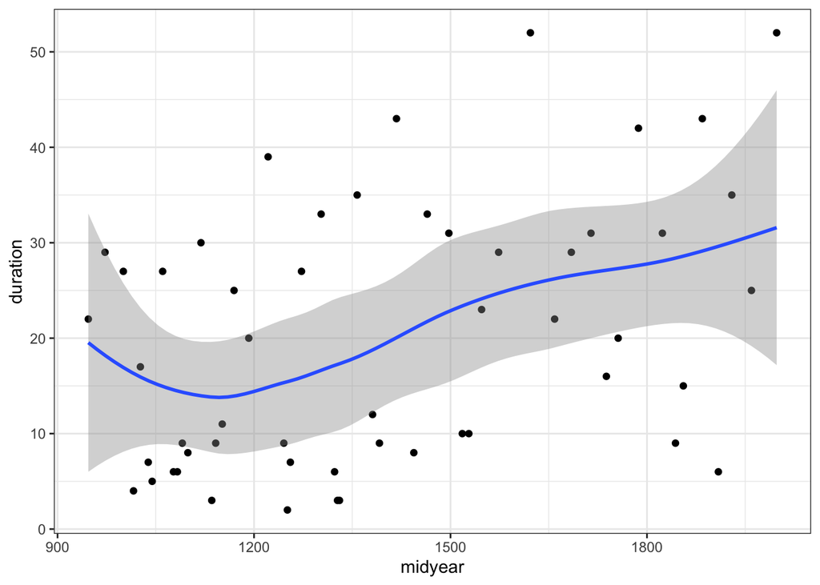

```r
kings %>%
  mutate(midyear=Start_regeringsperiode+duration/2) %>%
  mutate(navn_titel=paste(Titel)) %>%
  ggplot(aes(x=midyear, y=duration))+
  geom_point()+
  geom_smooth()+
  theme_bw()
```

And to submit this rmarkdown, knit it into html. But first, clean up the code chunks, adjust the date, rename the author and change the `eval=FALSE` flag to `eval=TRUE` so your script actually generates an output. Well done!